# Data Wrangling I

Activity 05

Author

Solutions

## Overview

The focus of Activity 05 will be on data wrangling. In real data applications it is rare that data will be in the “perfect” form for us to use. We will typically need to manipulate or wrangle the data into a form that is useful. We will begin our development of data wrangling skills by becoming familiar with the “pipe”, `%>%`, and using it with `filter()` and `summarize()`. We will also utilize our visualization tools from the previous activities.

## Needed Packages

The following loads the packages that are needed for this activity. We assume that you have installed the packages. Also note that we have suppressed the `message`s so the compiled html is less cluttered.

```r
library(dplyr)
library(ggplot2)
library(nycflights13)
```

## Tasks

Complete the following series of tasks. Remember to **render early and render often**.

### Background

#### Chicago flight times

We will be using the familiar `flights` dataset from `nycflights13` for this section. It might be useful to review the dataset a little. Run `?flights` in your console and a help file will appear with information about the dataset. You might find the definitions for the variables useful. It is also advisable to take a quick peek at the data by running `View(flights)` in your console — remember never to run/leave this in your Rmd file because it will produce an error.

## Task 1

### O’hare (ORD)

Let’s focus on flights from New York City to Chicago’s O’hare (`ORD`). Create a dataset named `ord_flights` that contains all flights in 2013 to `ORD` from New York City’s airports.

```r
# create ord_flights
ord_flights <- flights %>%
  filter(dest == "ORD")
```

It is always a good idea to inspect your newly created dataset as a quick spot check. You can do that by printing it (run `ord_flights` in the console), by `View()`ing it, and/or checking that it is in the **Environment** tab in the upper right pane.

How many flights are in `ord_flights`? Does each flight correspond to an observation or variable?

**There are 17,283 flights in `ord_flights`.**

We are interested in the flight time as measured by `air_time` from NYC to Chicago’s `ORD`. That is, we want to investigate the distribution of `air_time`. Begin the investigation by calculating summary statistics: mean, standard deviation, median, interquartile range, minimum, and maximum. Store the results in `ord_summary`.

```r
# Create ord_summary
ord_summary <- ord_flights %>%
  summarize(
    avg     = mean(air_time, na.rm = TRUE),
    std_dev = sd(air_time, na.rm = TRUE),
    med     = median(air_time, na.rm = TRUE),
    iqr     = IQR(air_time, na.rm = TRUE),
    minimum = min(air_time, na.rm = TRUE),
    maximum = max(air_time, na.rm = TRUE)
  )
# Print ord_summary
ord_summary
```

```
# A tibble: 1 × 6
    avg std_dev   med   iqr minimum maximum
  <dbl>   <dbl> <dbl> <dbl>   <dbl>   <dbl>
1  116.    10.2   114    13      87     198
```

Explain what these values tell you about the flight times from NYC airports to Chicago’s O’hare in 2013. That is, what is the typical flight time? How do flights spread out or deviate from the typical flight time?

**The typical flight time from an NYC airport to Chicago’s O’hare in 2013 took about 116 minutes. The distribution of flight time for these flights has a spread, as measured by standard deviation, of about 10.2 minutes. This information would indicate that most of the flights between NYC airports and ORD took about 96 to 136 minutes. Found values by taking 116 - 2*10 and 116 + 2*10.**

It might be useful to also visualize the distribution of `air_time`. You should use two of the 5NGs to do this. Create the two graphs in the code chunk below.

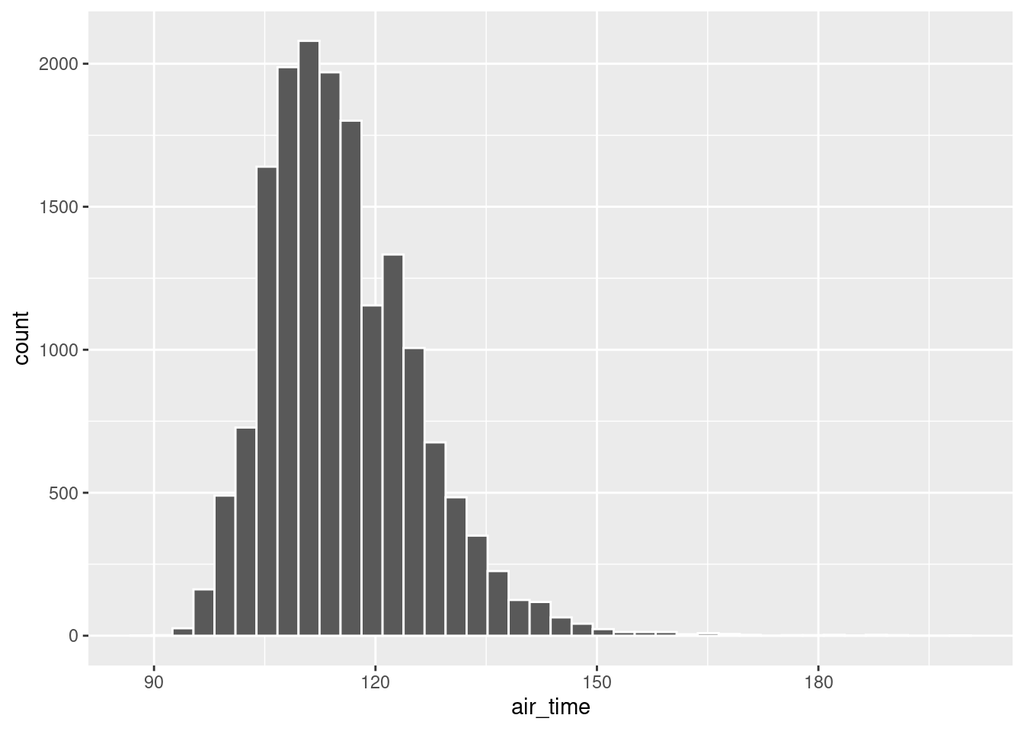

```r
# Construct plot 1
ggplot(ord_flights, aes(x = air_time)) +
  geom_histogram(color = "white", bins = 40)
```

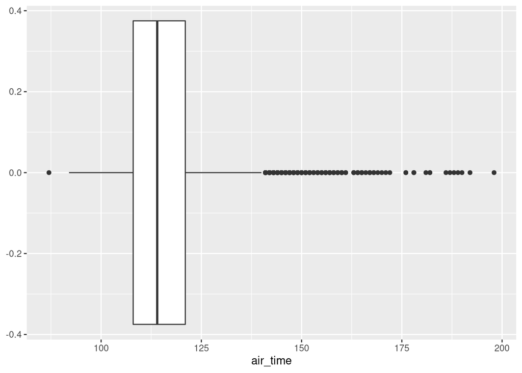

```r
# Construct plot 2
ggplot(ord_flights, aes(y = air_time)) +
  geom_boxplot() +
  coord_flip()
```

Do the summary statistics and plots above tell the same story about `air_time`? Explain.

**Yes, the summary statistics and plots tell the a similar story. We see the center is about 116 minutes and the spread is around 13 minutes (IQR). The interval we mentioned above covers the vast majority of the data. One thing that is easier to see in the graphs is that there is a slight right skew in the distribution as a result of there being several outliers to the right. The mean being to the right of the median does imply that there are outliers to the right (therefore possible right skew).**

## Task 2

### The useful `is.na()` function

When calculating the summary statistics above and building the graphs we had to take care of missing values for `air_time`. How does a flight have `NA` for its `air_time`? Either there was a recording error (unlikely with [FAA](https://www.faa.gov/) records) or maybe the flight was cancelled. When analyzing flight time (`air_time`) do we really care about flights that were cancelled? Probably not, so we could filter them out.

This means we need a way of identifying if a flight has `NA` for its `air_time` measurement. Your first instinct should be to use something like `air_time != NA` (keep `air_time` that are not equal to `NA`), but that won’t do the trick. Missing values are tricky and handling them takes a little extra care. We need the `is.na()` function which does exactly what it seems to imply. It answers the question “`TRUE` or `FALSE`: Is the input `NA`?”

Now if we use `is.na(air_time)` in a filter we would be keeping the flights that have `NA` for `air_time` which is the opposite of what we want. Therefore we should use `!is.na(air_time)`. Create a dataset named `ord_not_cancelled` that contains all flights from NYC to `ORD` that were not cancelled.

```r
# Create ord_not_cancelled
ord_not_cancelled <- flights %>%
  filter(dest == "ORD", !is.na(air_time))
# Print ord_not_cancelled
ord_not_cancelled
```

```
# A tibble: 16,566 × 19
    year month   day dep_time sched_dep_time dep_delay arr_time sched_arr_time
   <int> <int> <int>    <int>          <int>     <dbl>    <int>          <int>
 1  2013     1     1      554            558        -4      740            728
 2  2013     1     1      558            600        -2      753            745
 3  2013     1     1      608            600         8      807            735
 4  2013     1     1      629            630        -1      824            810
 5  2013     1     1      656            700        -4      854            850
 6  2013     1     1      709            700         9      852            832
 7  2013     1     1      715            713         2      911            850
 8  2013     1     1      739            745        -6      918            930
 9  2013     1     1      749            710        39      939            850
10  2013     1     1      828            830        -2     1027           1012
# … with 16,556 more rows, and 11 more variables: arr_delay <dbl>,
#   carrier <chr>, flight <int>, tailnum <chr>, origin <chr>, dest <chr>,
#   air_time <dbl>, distance <dbl>, hour <dbl>, minute <dbl>, time_hour <dttm>
```

Now there should be no missing value issues with `air_time`. Test this out by re-running one of your graphs, but use the `ord_not_cancelled` dataset. There shouldn’t be a warning message this time because we removed all the flights that had missing values.

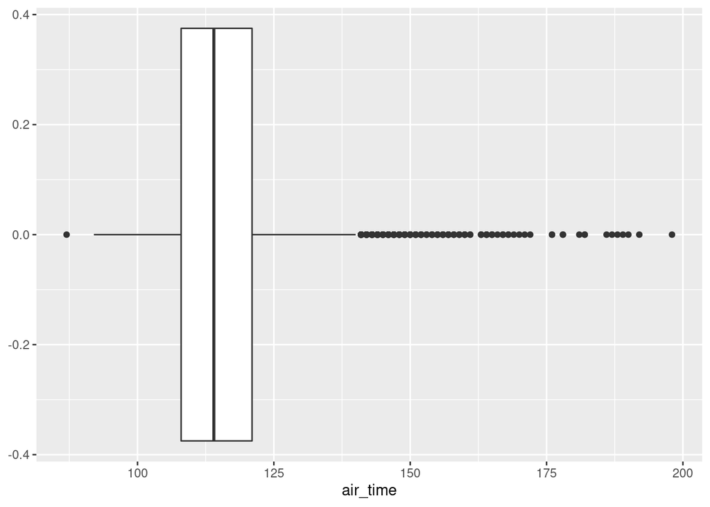

```r
ggplot(ord_not_cancelled, aes(y = air_time)) +
  geom_boxplot() +
  coord_flip()
```

**It is important to note** that we didn’t just throw out missing values. We thought about them and determined that they represented flights that had no impact on what we were exploring and could be removed.

This is a very useful function that you may be using often so I recommend making a note of it somewhere!

## Task 3

### Additional practice

Suppose we want to **count** the total number of flights that were

- in the `month` of January,
- and departed late Hint: if they departed late think about which (`dep_delay`) values you want to keep

Store your results in `delay_jan`.

```r
# Create delay_jan
delay_jan <- flights %>%
  filter(month == 1, dep_delay>0) %>%
  summarize(count = n())
# Print delay_jan
delay_jan
```

```
# A tibble: 1 × 1
  count
  <int>
1  9662
```

## Task 4

### More practice

Suppose we want to summarize the average and standard deviation of `arr_delay` for flights

- headed to `ORD` or `MDW`,
- and in the month of June

Store your results in `arr_june`.

```r
# Create arr_june
arr_june <- flights %>%
  filter((dest =='ORD' | dest =='MDW'), month == 6) %>%
  summarize(mean = mean(arr_delay, na.rm=TRUE),
            sd = sd(arr_delay, na.rm=TRUE))
# Print arr_june
arr_june
```

```
# A tibble: 1 × 2
   mean    sd
  <dbl> <dbl>
1  14.8  55.9
```

## Optional Challenge

**Do not have to complete.**

Copy and paste your code used to create `ord_not_cancelled`, but remove the `ord_not_cancelled <-`. We don’t want to store it. What happens when you run the code?

```r
# PLACE CODE HERE
flights %>%
  filter(dest == "ORD", !is.na(air_time))
```

```
# A tibble: 16,566 × 19
    year month   day dep_time sched_dep_time dep_delay arr_time sched_arr_time
   <int> <int> <int>    <int>          <int>     <dbl>    <int>          <int>
 1  2013     1     1      554            558        -4      740            728
 2  2013     1     1      558            600        -2      753            745
 3  2013     1     1      608            600         8      807            735
 4  2013     1     1      629            630        -1      824            810
 5  2013     1     1      656            700        -4      854            850
 6  2013     1     1      709            700         9      852            832
 7  2013     1     1      715            713         2      911            850
 8  2013     1     1      739            745        -6      918            930
 9  2013     1     1      749            710        39      939            850
10  2013     1     1      828            830        -2     1027           1012
# … with 16,556 more rows, and 11 more variables: arr_delay <dbl>,
#   carrier <chr>, flight <int>, tailnum <chr>, origin <chr>, dest <chr>,
#   air_time <dbl>, distance <dbl>, hour <dbl>, minute <dbl>, time_hour <dttm>
```

Now build on that code by piping it directly into the histogram code. That is add a `%>%` to the end of code from the previous chunk and paste your code for a histogram of `air_time` right after it. Remove the data reference from your `ggplot()` code. That is remove `data = ord_not_cancelled` from the the base layer so it now looks like `ggplot(mapping = aes(x = air_time))`. Run the code. What happens?

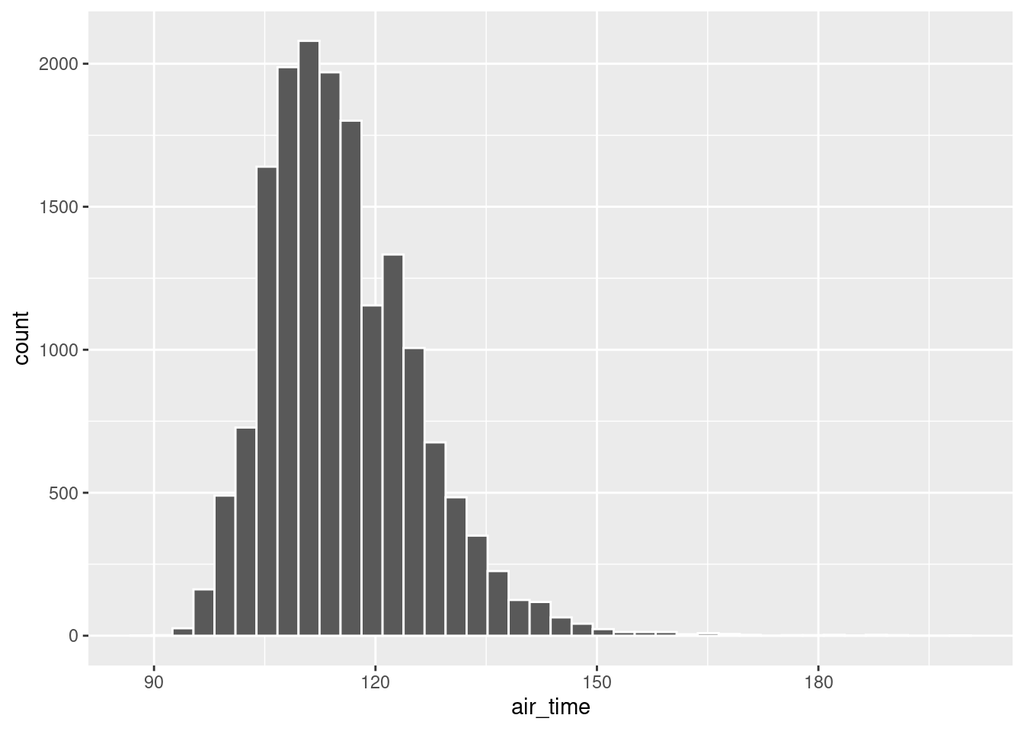

```r
flights %>%
  filter(dest == "ORD", !is.na(air_time)) %>%
  ggplot(aes(x = air_time)) +
  geom_histogram(color = "white", bins = 40)
```

Why might this be useful?

**We don’t have to waste time saving intermediate datasets and we can make minor adjustments without having to re-create intermediate datasets.**